# Flexible Damage Functions

Author

James Rising, Sebastian Cadavid Sanchez, Climate Impact Lab

Published

April 30, 2026

## 0.1 Agriculture: Wheat Winter Country

Flexible damage function parameters at the Country level.

**Change in winter wheat yields (log change in yields) under full adaptation**

**Outcome units:** `physical` — log change in wheat winter yield (population-weighted to country)

$$D_{it} = (\alpha_i T_t + \beta_i T_t^2) \cdot Y_{it}^{\gamma}$$

where $\gamma$ is the income elasticity (fitted globally), $\alpha_i$ is the linear coefficient, and $\beta_i$ is the quadratic coefficient.

# 1 Global Estimation

## 1.1 Income Elasticity Estimation

The income elasticity $\gamma$ is estimated using a fixed-effects regression:

$$y_{it} = \gamma \cdot \log(Y_{it}) + \mu_{g(i,T)} + \nu_t + \varepsilon_{it}$$

where $\mu_{g(i,T)}$ are region-by-temperature-bin fixed effects and $\nu_t$ are year fixed effects.

Table 1: Income Elasticity (Gamma) Estimation Results

| Statistic | Value |
| --- | --- |
| Income elasticity ($\gamma$) | -0.0860 |
| Standard error | 8.37e-03 |
| 95% CI | [-0.1024, -0.0696] |
| R-squared | 0.6717 |
| Observations | 1,913,535 |
| Regions | 138 |
| Gamma quantiles | 19 |

# 2 Parameter Distributions

## 2.1 8-Panel Summary

Row 1: gamma, alpha, beta, rsqr1. Row 2: rho, zeta, eta, rsqr2.

```
Using median gamma: -0.085983, 138 rows (of 2,622 total)
```

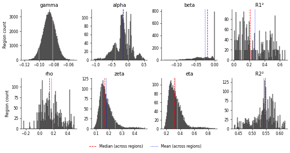

Figure 1: Distribution of Regional Parameters

## 2.2 Projection Equation and Parameter Definitions

The estimated parameters are used to project damages via Monte Carlo sampling:

$$D_{it}^k = (\hat{\alpha}_{ik} T_t + \hat{\beta}_{ik} T_t^2) Y_{it}^{\hat{\gamma}_k} + \hat{\theta}_{ik} T_t Y_{it}^{\hat{\gamma}_k} + \hat{\phi}_{it}^k$$

where $k$ indexes the Monte Carlo draw. The parameters in each row of the output CSV control distinct components of this equation:

- **gamma**: income elasticity $\hat{\gamma}_k$, one of 19 quantile values drawn from $N(\hat{\gamma}, SE(\hat{\gamma}))$
- **alpha, beta**: linear and quadratic temperature coefficients; $\hat{\alpha}_{ik}$ and $\hat{\beta}_{ik}$ are drawn from the joint normal defined by the VCV below
- **sigma11, sigma12, sigma22**: variance-covariance matrix of $(\alpha, \beta)$, used for joint uncertainty sampling
- **rho**: correlation between regional and global polynomial residuals $\rho_i$, used to maintain spatial covariance across regions in Monte Carlo draws
- **zeta**: temperature-dependent error scale $\zeta_{ik}$; the run-specific error term $\hat{\theta}_{ik}$ is drawn from $N(0, \zeta_{ik})$
- **eta**: residual noise standard deviation $\eta_{ik}$; the annual noise $\hat{\phi}_{it}^k$ is drawn from $N(0, \eta_{ik})$
- **rsqr1, rsqr2**: polynomial fit quality and error model fit, respectively

## 2.3 Summary Statistics

Table 2: Regional Parameter Summary

| Parameter | Mean | Median | Std | Min | Max | N |
| --- | --- | --- | --- | --- | --- | --- |
| alpha | -0.1547 | -0.1543 | 0.2514 | -0.9037 | 0.4556 | 138 |
| beta | -0.02545 | -0.02033 | 0.02577 | -0.1146 | 0 | 138 |
| rho | 0.1675 | 0.1422 | 0.144 | -0.2286 | 0.4925 | 138 |
| zeta | 0.1793 | 0.1684 | 0.05271 | 0.09561 | 0.4121 | 138 |
| eta | 0.3258 | 0.3082 | 0.09422 | 0.193 | 0.7701 | 138 |
| rsqr1 | 0.2702 | 0.2104 | 0.1859 | 0.004242 | 0.6654 | 138 |
| rsqr2 | 0.5408 | 0.5465 | 0.03904 | 0.4367 | 0.6188 | 138 |

# 3 Spaghetti Curves

Regional damage function curves showing D(T) = αT + βT² for sampled regions.

[interactive chart not shown]

Figure 2: Regional Damage Functions

# 4 Zero Crossings

The zero crossing (extremum) of the parabola occurs at $T^* = -\alpha / (2\beta)$.

Table 3: Zero Crossing Statistics

| Category | Count | Percentage |
| --- | --- | --- |
| β = 0 (no crossing) | 40 | 29.0% |
| T > 20°C (beyond graph) | 0 | 0.0% |
| T < 0°C (negative crossing) | 63 | 45.7% |
| Valid crossings (0-20°C) | 35 | 25.4% |

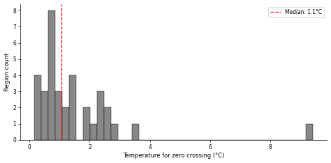

Figure 3: Distribution of Zero Crossing Temperatures

# 5 Slope Analysis

Maximum slope between 0 and 10°C: $\frac{dM}{dT} = \alpha + 2\beta T$

The maximum occurs at either T=0 or T=10 (endpoints of interval).

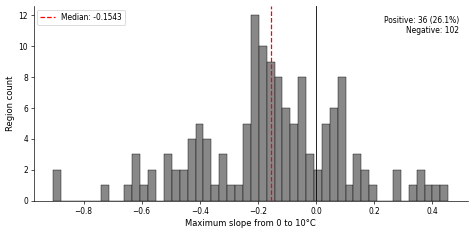

Figure 4: Distribution of Maximum Slopes (0-10°C)

*Convexity analysis omitted (beta constraint active).*

# 6 R-squared Analysis

## 6.1 Polynomial Fit Quality (rsqr1)

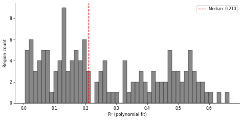

Figure 5: Regional Fit Quality (R-squared)

## 6.2 Error Model R-squared (rsqr2) Quantiles

Table 4: rsqr2 Quantiles

| 0% (Min) | 25% | 50% (Median) | 75% | 100% (Max) |
| --- | --- | --- | --- | --- |
| 0.4367 | 0.5207 | 0.5465 | 0.5688 | 0.6188 |

# 7 Modelled Variance

Modelled variance statistic: $1 - \frac{\sum_i \eta_i^2}{\sum_i D_i^2}$

Table 5: Modelled Variance Statistics

| Statistic | Value |
| --- | --- |
| Modelled variance | 0.8674 |
| Sum(η²) | 15.8682 |
| Sum(D²) at T=3.0°C | 119.6303 |
| N regions | 138 |

# 8 Best- and Worst-Fitting Regions

Table 6: Best- and worst-fitting regions

Top 3 best fit (R²) Top 3 worst fit (R²)

[output not shown]

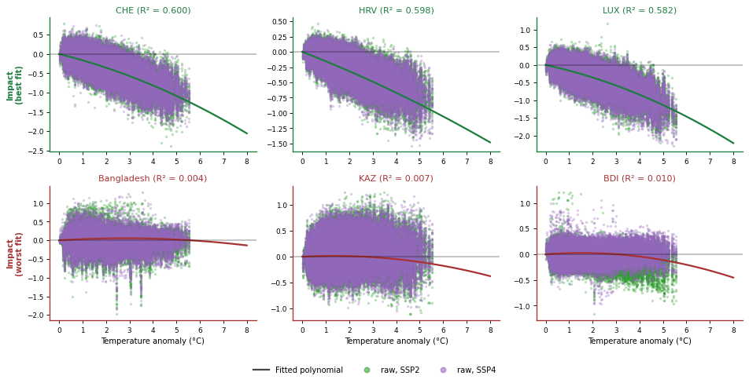

# 9 Regional Parameter Maps

Maps of key parameters at the **country** level. Red = negative (damage increases with T), Blue = positive.

## 9.1 Alpha (Linear Coefficient)

Alpha ($\alpha$) represents the linear sensitivity to temperature. Regions with negative alpha experience damage that increases with the first degree of warming.

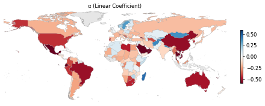

Figure 7: α (linear coefficient)

## 9.2 Beta (Quadratic Coefficient)

Beta ($\beta$) represents the curvature of the damage function.

The concavity ($\beta \leq 0$) constraint is enforced for this sector, meaning optimal temperature exists, damages accelerate beyond it.

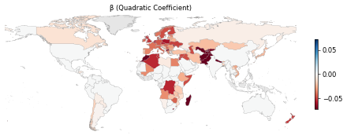

Figure 8: β (quadratic coefficient)

## 9.3 R-squared (Fit Quality)

$R^2$ measures the polynomial fit quality. Higher values indicate that the quadratic form captures more of the variance in the data.

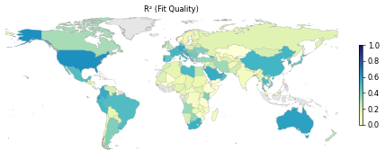

Figure 9: R² (stage 1 fit quality)

# 10 F2: Flex vs Raw Comparison

Comparison of flexible damage function predictions against raw simulation means.

For each scenario (RCP × SSP × Model), we compute at the final year:

- **Flex predicted**: $(\alpha \cdot T + \beta \cdot T^2) \cdot Y^\gamma$
- **Raw actual**: The outcome variable (y) from the source data

**Year 2098**: 971,520 rows

**rcp45**

**SSP2**

**high**

**Correlation:** 0.6934 | **RMSE:** 0.118175 | **Sign agreement:** 89.1%

[interactive chart not shown]

Top 5 best predicted Top 5 worst predicted

Year 2098 · T<sub>mean</sub> across these regions: 1.94°C

| Region | Raw | Flex | Residual |
| --- | --- | --- | --- |
| BLR | -0.137 | -0.138 | -0.00117 |
| NAM | -0.175 | -0.178 | -0.00334 |
| BTN | -0.25 | -0.254 | -0.00356 |
| GUY | 0.0579 | 0.0622 | 0.00429 |
| GRC | -0.132 | -0.138 | -0.00591 |
| THA | -0.271 | -0.646 | -0.375 |
| MDG | -0.124 | 0.217 | 0.342 |
| LSO | -0.217 | 0.122 | 0.338 |
| TKM | 0.0023 | -0.289 | -0.291 |
| NCL | -0.133 | -0.422 | -0.289 |

**low**

**Correlation:** 0.7130 | **RMSE:** 0.115560 | **Sign agreement:** 89.9%

[interactive chart not shown]

Top 5 best predicted Top 5 worst predicted

Year 2098 · T<sub>mean</sub> across these regions: 1.94°C

| Region | Raw | Flex | Residual |
| --- | --- | --- | --- |
| CHL | -0.0902 | -0.0924 | -0.00221 |
| JPN | -0.158 | -0.154 | 0.0041 |
| GRC | -0.141 | -0.135 | 0.00569 |
| GUY | 0.0594 | 0.0652 | 0.00573 |
| LTU | -0.073 | -0.0652 | 0.00787 |
| THA | -0.258 | -0.675 | -0.417 |
| TKM | 0.00902 | -0.292 | -0.301 |
| NCL | -0.123 | -0.422 | -0.3 |
| MYS | 0.0816 | -0.206 | -0.288 |
| MDG | -0.0391 | 0.245 | 0.284 |

**SSP4**

**high**

**Correlation:** 0.7246 | **RMSE:** 0.113172 | **Sign agreement:** 88.4%

[interactive chart not shown]

Top 5 best predicted Top 5 worst predicted

Year 2098 · T<sub>mean</sub> across these regions: 1.94°C

| Region | Raw | Flex | Residual |
| --- | --- | --- | --- |
| UGA | -0.13 | -0.131 | -7.84e-4 |
| HND | -0.0515 | -0.05 | 0.00159 |
| BTN | -0.258 | -0.261 | -0.00294 |
| UKR | -0.219 | -0.216 | 0.00364 |
| PRK | -0.155 | -0.151 | 0.00423 |
| THA | -0.287 | -0.653 | -0.366 |
| MDG | -0.0357 | 0.253 | 0.289 |
| LSO | -0.144 | 0.14 | 0.284 |
| TKM | -0.0141 | -0.287 | -0.273 |
| MYS | 0.0553 | -0.193 | -0.249 |

**low**

**Correlation:** 0.6815 | **RMSE:** 0.129738 | **Sign agreement:** 86.2%

[interactive chart not shown]

Top 5 best predicted Top 5 worst predicted

Year 2098 · T<sub>mean</sub> across these regions: 1.94°C

| Region | Raw | Flex | Residual |
| --- | --- | --- | --- |
| BDI | 0.0276 | 0.0261 | -0.00154 |
| GRC | -0.138 | -0.136 | 0.00201 |
| HND | -0.0482 | -0.0508 | -0.00261 |
| MWI | -0.00846 | -0.0155 | -0.00708 |
| UGA | -0.145 | -0.138 | 0.0074 |
| THA | -0.208 | -0.717 | -0.508 |
| TKM | 0.0231 | -0.3 | -0.323 |
| MDG | -0.0199 | 0.262 | 0.282 |
| LSO | -0.133 | 0.149 | 0.282 |
| OMN | -0.212 | -0.481 | -0.269 |

**rcp85**

**SSP2**

**high**

**Correlation:** 0.8106 | **RMSE:** 0.177110 | **Sign agreement:** 95.7%

[interactive chart not shown]

Top 5 best predicted Top 5 worst predicted

Year 2098 · T<sub>mean</sub> across these regions: 4.17°C

| Region | Raw | Flex | Residual |
| --- | --- | --- | --- |
| ALB | -0.449 | -0.449 | -6.24e-5 |
| AGO | -0.47 | -0.47 | 2.12e-4 |
| PRY | -0.387 | -0.389 | -0.00144 |
| SOM | -0.124 | -0.119 | 0.00437 |
| KOR | -0.707 | -0.711 | -0.00456 |
| THA | -0.601 | -1.39 | -0.787 |
| MDG | -0.324 | 0.123 | 0.447 |
| MAR | -0.774 | -0.333 | 0.441 |
| LSO | -0.385 | 0.033 | 0.418 |
| ARE | -0.928 | -1.34 | -0.415 |

**low**

**Correlation:** 0.8361 | **RMSE:** 0.172852 | **Sign agreement:** 94.9%

[interactive chart not shown]

Top 5 best predicted Top 5 worst predicted

Year 2098 · T<sub>mean</sub> across these regions: 4.17°C

| Region | Raw | Flex | Residual |
| --- | --- | --- | --- |
| BIH | -0.686 | -0.685 | 0.00135 |
| ARG | -0.396 | -0.393 | 0.00312 |
| EST | -0.236 | -0.239 | -0.0032 |
| LTU | -0.237 | -0.233 | 0.004 |
| FIN | -0.2 | -0.194 | 0.00609 |
| THA | -0.575 | -1.45 | -0.876 |
| ECU | -0.65 | -1.08 | -0.429 |
| ARE | -0.937 | -1.34 | -0.406 |
| TKM | -0.236 | -0.628 | -0.392 |
| NCL | -0.523 | -0.907 | -0.384 |

**SSP4**

**high**

**Correlation:** 0.8300 | **RMSE:** 0.171687 | **Sign agreement:** 93.5%

[interactive chart not shown]

Top 5 best predicted Top 5 worst predicted

Year 2098 · T<sub>mean</sub> across these regions: 4.17°C

| Region | Raw | Flex | Residual |
| --- | --- | --- | --- |
| BTN | -0.647 | -0.649 | -0.00207 |
| CAN | -0.39 | -0.385 | 0.00482 |
| KO- | -0.534 | -0.542 | -0.00778 |
| ALB | -0.457 | -0.447 | 0.0093 |
| USA | -0.637 | -0.648 | -0.0103 |
| THA | -0.61 | -1.4 | -0.793 |
| MMR | -0.235 | -0.681 | -0.446 |
| ARE | -0.952 | -1.33 | -0.381 |
| MAR | -0.713 | -0.345 | 0.369 |
| ECU | -0.676 | -1.04 | -0.36 |

**low**

**Correlation:** 0.7793 | **RMSE:** 0.231793 | **Sign agreement:** 92.8%

[interactive chart not shown]

Top 5 best predicted Top 5 worst predicted

Year 2098 · T<sub>mean</sub> across these regions: 4.17°C

| Region | Raw | Flex | Residual |
| --- | --- | --- | --- |
| FIN | -0.197 | -0.194 | 0.00289 |
| GUY | 0.138 | 0.145 | 0.00694 |
| MNE | -0.685 | -0.673 | 0.0126 |
| ALB | -0.462 | -0.447 | 0.0147 |
| EST | -0.224 | -0.24 | -0.0165 |
| THA | -0.461 | -1.54 | -1.08 |
| VNM | -0.884 | -1.44 | -0.552 |
| ECU | -0.618 | -1.15 | -0.529 |
| ARE | -0.805 | -1.33 | -0.528 |
| TKM | -0.129 | -0.645 | -0.516 |

**Note · countries with no wheat winter data** (shown white on every map above; the GCP wheat winter pipeline does not run sims for non-producing countries): ABW, AIA, ALA, AND, ASM, ATA, ATF, ATG, BES, BHR, BHS, BLM, BMU, BRB, BRN, BVT, CCK, CIV, CL-, COK, COM, CPV, CRI, CUB, CUW, CXR, CYM, CYP, DJI, DMA, DOM, ESH, FJI, FLK, FRO, FSM, GAB, GGY, Ghana, GIB, GIN, GLP, GMB, GNB, GNQ, GRD, GRL, GUF, GUM, HKG, HMD, HTI, Indonesia, IMN, IOT, ISL, JAM, JEY, KHM, KIR, KNA, LBR, LCA, LIE, LKA, MAC, MAF, MCO, MDV, MHL, MNP, MSR, MTQ, MUS, MYT, NFK, NIU, NRU, PAN, PCN, Philippines, PLW, PNG, PRI, PYF, QAT, REU, SGP, SGS, SHN, SJM, SLB, SLE, SMX, SP-, SPM, STP, SUR, SYC, TCA, TGO, TKL, TLS, TON, TTO, TUV, TWN, UMI, VAT, VCT, VGB, VIR, VUT, WLF, WSM.

## 10.1 Scenario Summary

| RCP | SSP | Model | N | Corr | RMSE | Sign% |
| --- | --- | --- | --- | --- | --- | --- |
| rcp45 | SSP2 | high | 138 | 0.6934 | 0.118175 | 89.1% |
| rcp45 | SSP2 | low | 138 | 0.713 | 0.11556 | 89.9% |
| rcp45 | SSP4 | high | 138 | 0.7246 | 0.113172 | 88.4% |
| rcp45 | SSP4 | low | 138 | 0.6815 | 0.129738 | 86.2% |
| rcp85 | SSP2 | high | 138 | 0.8106 | 0.17711 | 95.7% |
| rcp85 | SSP2 | low | 138 | 0.8361 | 0.172852 | 94.9% |
| rcp85 | SSP4 | high | 138 | 0.83 | 0.171687 | 93.5% |
| rcp85 | SSP4 | low | 138 | 0.7793 | 0.231793 | 92.8% |

# 11 Data Reference

## 11.1 File Locations

| Item | Path |
| --- | --- |
| Regional CSV | `/project/cil/gcp/flex_damage_funcs/parameters/agriculture__wheat_winter_country__regional_parameters.csv` |
| Global JSON | `/project/cil/gcp/flex_damage_funcs/parameters/agriculture__wheat_winter_country__global_results.json` |
| Metadata JSON | `/project/cil/gcp/flex_damage_funcs/parameters/agriculture__wheat_winter_country__metadata.json` |

## 11.2 Column Definitions

| Column | Description |
| --- | --- |
| `region` | Region identifier (hierarchical code, first 3 chars = country ISO3) |
| `gamma` | Income elasticity quantile value |
| `alpha` | Linear temperature coefficient |
| `beta` | Quadratic temperature coefficient |
| `sigma11` | Var(alpha) |
| `sigma12` | Cov(alpha, beta) |
| `sigma22` | Var(beta) |
| `rho` | Correlation with global residual process |
| `zeta` | Temperature-dependent heteroskedasticity |
| `eta` | Residual standard deviation |
| `rsqr1` | R-squared of polynomial fit |
| `rsqr2` | R-squared of error model |

*Report generated with FlexDamage v1.0.0*